# Entreprise Telco :

## Random Forest de Breiman

Il s’agit d’un algorithme qui effectue un apprentissage en parallèle sur de multiples arbres de décision construits aléatoirement et entraînés sur des sous-ensembles de données différents. Le nombre idéal d’arbres, qui peut aller jusqu’à plusieurs centaines voire plus, est un paramètre important : il est très variable et dépend du problème. Concrètement, chaque arbre de la forêt aléatoire est entrainé sur un sous ensemble aléatoire de données selon le principe du bagging, avec un sous ensemble aléatoire de features (caractéristiques variables des données) selon le principe des « projections aléatoires ». Les prédictions sont ensuite moyennées lorsque les données sont quantitatives ou utilisés pour un vote pour des données qualitatives, dans le cas des arbres de classification. L’algorithme des forêts aléatoires est connu pour être un des classifieurs les plus efficaces « out-of-the-box » (c’est-à-dire nécessitant peu de prétraitement des données). Il a été utilisé dans de nombreuses applications, y compris grand public, comme pour la classification d’images de la caméra de console de jeu Kinect* dans le but d’identifier des positions du corps.

Nous testons tous d’abord un randomForest avec des paramètres basiques prédéfinis dans la fonction.

```r
set.seed(496)
#Entraînement du modèle
rf.1 <- randomForest(x = X_train,y=y_train, importance = FALSE, ntree = 500)
rf.1
```

```
##
## Call:
##  randomForest(x = X_train, y = y_train, ntree = 500, importance = FALSE)
##                Type of random forest: classification
##                      Number of trees: 500
## No. of variables tried at each split: 6
##
##         OOB estimate of  error rate: 20%
## Confusion matrix:
##      0   1 class.error
## 0 3791 368  0.08848281
## 1  759 717  0.51422764
```

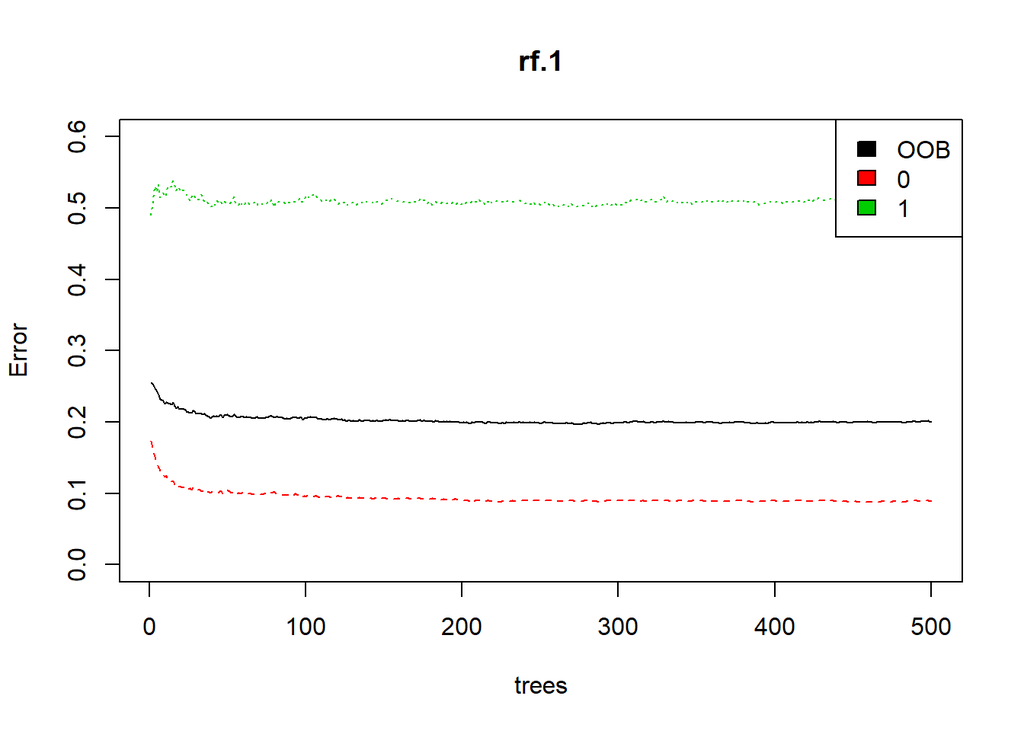

```r
#graoh permettant de visualiser le taux de mauvais classement en fonction du nombre d'arbre
plot(rf.1, ylim=c(0,0.6))
legend('topright', colnames(rf.1$err.rate), col=1:3, fill=1:3)
```

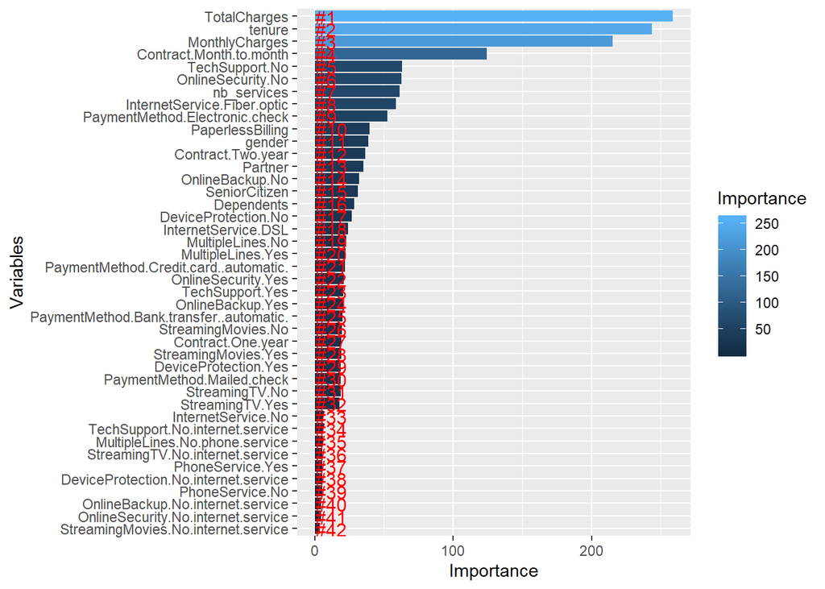

```r
importance<- importance(rf.1)
#Attribution de l'importance des variables par Moyenne decroissante du coefficient de Gini
varImportance <- data.frame(Variables = row.names(importance),Importance = round(importance[ ,'MeanDecreaseGini'],2))

# Classement des bariables par niveau d'importance
rankImportance <- varImportance %>%
  mutate(Rank = paste0('#',dense_rank(desc(Importance))))

# Graph permettant d evisualiser l'importance des varaibles
ggplot(rankImportance, aes(x = reorder(Variables, Importance),
    y = Importance, fill = Importance)) +
  geom_bar(stat='identity') +
  geom_text(aes(x = Variables, y = 0.5, label = Rank),
    hjust=0, vjust=0.55, size = 4, colour = 'red') +
  labs(x = 'Variables') +
  coord_flip()
```

```r
#Résultats
pred=predict(rf.1,newdata = X_test)
confusionMatrix(pred,y_test)
```

```
## Confusion Matrix and Statistics
##
##           Reference
## Prediction   0   1
##          0 920 199
##          1  95 194
##
##                Accuracy : 0.7912
##                  95% CI : (0.769, 0.8122)
##     No Information Rate : 0.7209
##     P-Value [Acc > NIR] : 8.631e-10
##
##                   Kappa : 0.4353
##
##  Mcnemar's Test P-Value : 1.889e-09
##
##             Sensitivity : 0.9064
##             Specificity : 0.4936
##          Pos Pred Value : 0.8222
##          Neg Pred Value : 0.6713
##              Prevalence : 0.7209
##          Detection Rate : 0.6534
##    Detection Prevalence : 0.7947
##       Balanced Accuracy : 0.7000
##
##        'Positive' Class : 0
##
```

```r
rf.roc <- roc(response = y_test, predictor = as.numeric(pred))
```

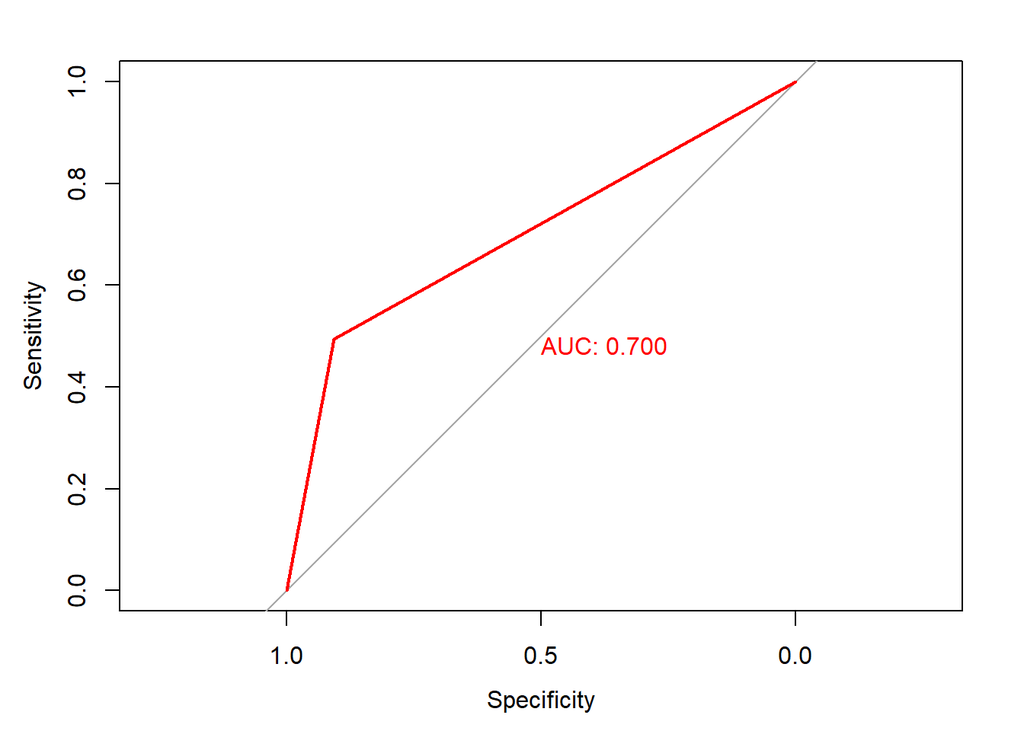

```r
plot(rf.roc, col = "red",print.auc = TRUE)
```

```r
187/(171+187)
```

```
## [1] 0.5223464
```

Observations: Dans ce premier randomFOrest réalisé, nous pouvons voir quelques éléments importants: Le premier graph nous montre le taux d’erreur du modèle entraîné en fonction du nombre d’arbre sélectionné. NOus pouvons voir que dans notre cas précis, augmenter de beaucoup les arbres ne serait pas très efficace car cela ne nous ferait pas gagner plus de précision( diminution du taux d’erreur). Nous pouvons voir qu’à partir de 150 arbres le modèle ne s’améliore plus. Il ne sert donc à rien d’augmenter notre nombre d’arbre car cela serait gaspiller du temps inutilement et contribuer à du sur-aprentissage. NOus avons aussi à disposition un classement de variables par importance soit par décroissance de l’accuracy contribuée moyenne soit part par gini décroissant. Attardons nous sur le critère Gini, on peut y voir que les différentes variables n’ont pas la même importance dans le modèle. Certaines mêmes sont inutiles. Nous allons donc reproduire le même RandomFOrest en gardant nos variables majeures. Cela aura pour avantage de garder une bonne prédiction tout en limitant la durée du calcul.

```r
#Nouveau randomForest avec les 17 variables les plus importantes précédentes
set.seed(496)
rf.2 <- randomForest(x = X_train2,y=y_train2, importance = TRUE, ntree = 150)
rf.2
```

```
##
## Call:
##  randomForest(x = X_train2, y = y_train2, ntree = 150, importance = TRUE)
##                Type of random forest: classification
##                      Number of trees: 150
## No. of variables tried at each split: 4
##
##         OOB estimate of  error rate: 19.7%
## Confusion matrix:
##      0   1 class.error
## 0 3751 408   0.0981005
## 1  702 774   0.4756098
```

```r
pred2=predict(rf.2,newdata = X_test2)
confusionMatrix(pred2,y_test2)
```

```
## Confusion Matrix and Statistics
##
##           Reference
## Prediction   0   1
##          0 912 197
##          1 103 196
##
##                Accuracy : 0.7869
##                  95% CI : (0.7646, 0.8081)
##     No Information Rate : 0.7209
##     P-Value [Acc > NIR] : 8.351e-09
##
##                   Kappa : 0.4287
##
##  Mcnemar's Test P-Value : 7.902e-08
##
##             Sensitivity : 0.8985
##             Specificity : 0.4987
##          Pos Pred Value : 0.8224
##          Neg Pred Value : 0.6555
##              Prevalence : 0.7209
##          Detection Rate : 0.6477
##    Detection Prevalence : 0.7876
##       Balanced Accuracy : 0.6986
##
##        'Positive' Class : 0
##
```

```r
rf.roc2 <- roc(response = y_test2, predictor = as.numeric(pred2))
```

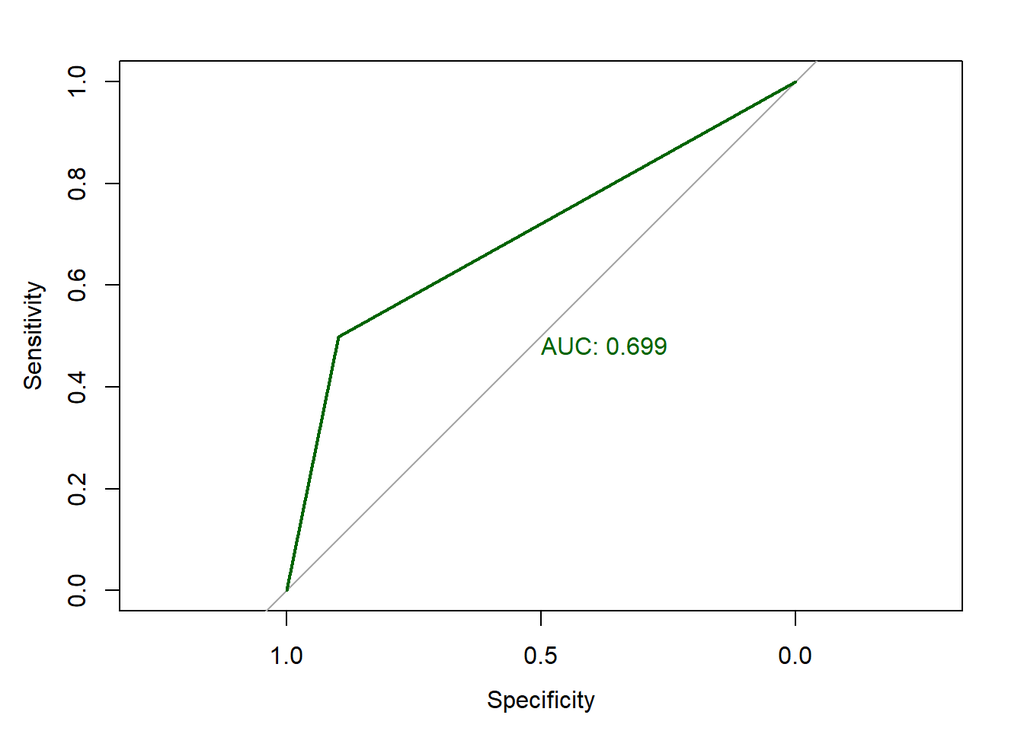

```r
plot(rf.roc2, col = "darkgreen",print.auc = TRUE)
```

L’AUC est moins bonne car on a supprimé de l’information mais moins de temps de calcul. Nous décidons donc de continuer avec l’ensemble des variables étant donné la taille résonnable de nos observations.

```r
library("mlbench")
library("caret")
library("randomForest")
set.seed(496)

#Paramètres Validation croisée
rf_Control <- trainControl(method = "cv", number = 5)


#Paramètre du RandomForest
tunegrid <- expand.grid(.mtry=c(25:42), .ntree=c(50,100,200))

#Customisation de notre RandomForest afin de l'adapter à notre situation avec les paramètres adéquats
customRF <- list(type = "Classification", library = "randomForest", loop = NULL)
customRF$parameters <- data.frame(parameter = c("mtry", "ntree"), class = rep("numeric", 2), label = c("mtry", "ntree"))
customRF$grid <- function(x, y, len = NULL, search = "grid") {}
customRF$fit <- function(x, y, wts, param, lev, last, weights, classProbs, ...) {
  randomForest(x, y, mtry = param$mtry, ntree=param$ntree, ...)
}

customRF$predict <- function(modelFit, newdata, preProc = NULL, submodels = NULL)
   predict(modelFit, newdata)
customRF$prob <- function(modelFit, newdata, preProc = NULL, submodels = NULL)
   predict(modelFit, newdata, type = "prob")
customRF$sort <- function(x) x[order(x[,1]),]
customRF$levels <- function(x) x$classes

#Entraînement du modèle
set.seed(496)
rf.cv<- train(x = X_train, y = y_train,  method=customRF, tuneGrid=tunegrid, trControl=rf_Control)
rf.cv
```

```
## 5635 samples
##   42 predictor
##    2 classes: '0', '1'
##
## No pre-processing
## Resampling: Cross-Validated (5 fold)
## Summary of sample sizes: 4508, 4508, 4508, 4507, 4509
## Resampling results across tuning parameters:
##
##   mtry  ntree  Accuracy   Kappa
##   25     50    0.7895267  0.4164230
##   25    100    0.7905932  0.4203842
##   25    200    0.7943175  0.4308142
##   26     50    0.7898827  0.4211204
##   26    100    0.7909498  0.4210666
```

[output cut: 52 more lines]

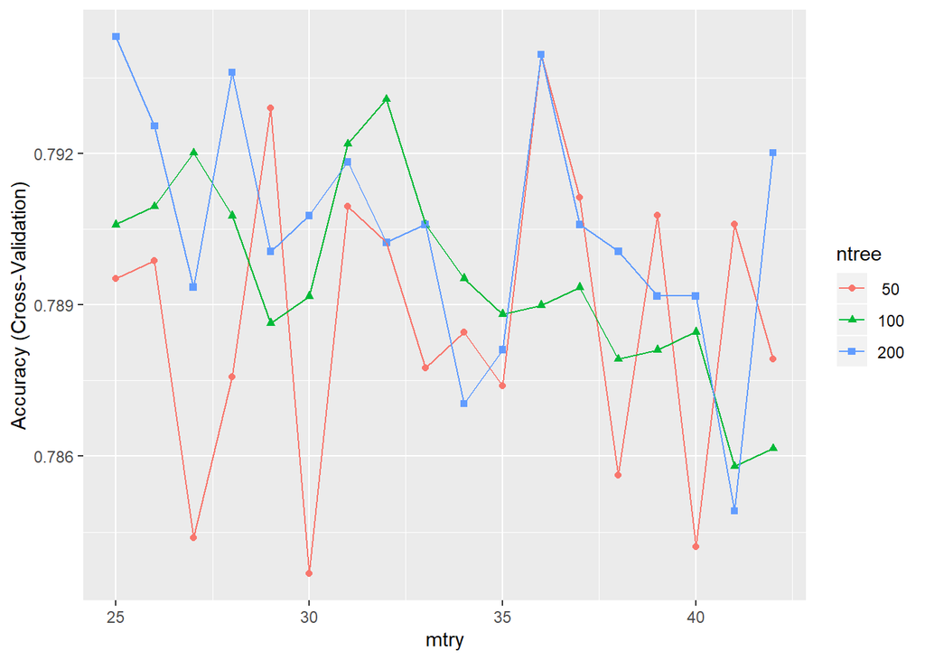

```r
#Evolution de l'accuracy en fonction des différents paramètres sélectionnés
ggplot(rf.cv)
```

```r
#Résultats
pred3 <- predict(rf.cv,test_val)
confusionMatrix(pred3,y_test)
```

```
## Confusion Matrix and Statistics
##
##           Reference
## Prediction   0   1
##          0 907 209
##          1 108 184
##
##                Accuracy : 0.7749
##                  95% CI : (0.7521, 0.7964)
##     No Information Rate : 0.7209
##     P-Value [Acc > NIR] : 2.330e-06
##
##                   Kappa : 0.3927
##
##  Mcnemar's Test P-Value : 1.948e-08
##
##             Sensitivity : 0.8936
##             Specificity : 0.4682
##          Pos Pred Value : 0.8127
##          Neg Pred Value : 0.6301
##              Prevalence : 0.7209
##          Detection Rate : 0.6442
##    Detection Prevalence : 0.7926
##       Balanced Accuracy : 0.6809
##
##        'Positive' Class : 0
##
```

```r
rf.roc3 <- roc(response = y_test, predictor = as.numeric(pred3))
```

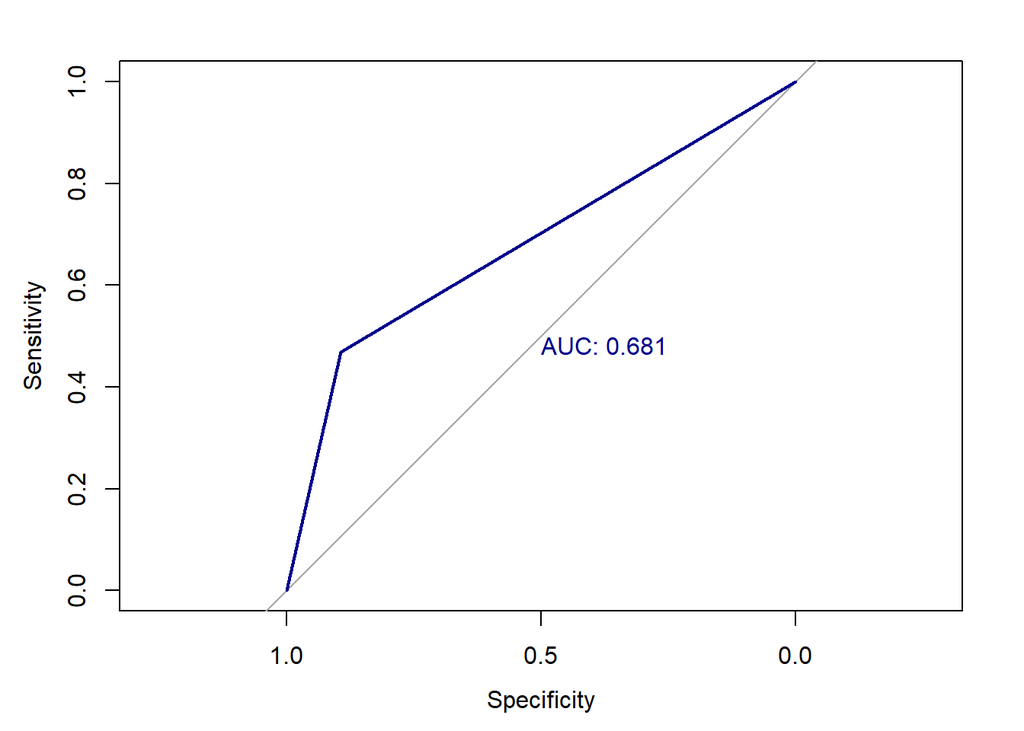

```r
plot(rf.roc3, col = "darkblue",print.auc = TRUE)
```

Résultat: Sans être exceptionnels, les résulats sont plutôt bon. Cependant on pense qu’on aurait encore eu de meilleurs résultats en faisant varier plus amplement le nombre de variables utilisées dans l’arbre (mtry). De même, les résultats auraient encore été plus robuste et meilleurs, si nous avions effectué une validation croisée répétée n fois (par 5 par exemple)

## Gradient Boosting

Les algorithmes de Boosting jouent un rôle crucial dans la conciliation biais variance. Contrairement aux algorithmes de bagging, qui ne contrôlent que les grosses variances dans le modèle, le boosting gère les 2 aspects, et est considéré comme plus efficace. En une explication succinte, le boosting peut-être vu comme une aggrégation d’une succesion d’arbres à faible pouvoir prédictif (weak learner) par des poids en fonction de si la prédiction est juste ou non. Ainsi, le boosting est une technique séquentielle qui marche sur le principes des ensembles. Il combine un ensemble de weak learners et offre une précision de prédiction améliorée. A tout instant t, les résultats du modèle sont pondérés en fonction en fonction des résultats de l’instant précédent t-1. Les resultats justes ont un poids attribué plus faible que les résultats non justes.

Le descente de gradient est la technique utilisée dans tous les aglgorithmes de boosting. Le but est d’utiliser l’algorithme afin de déterminer le minimum d’une fonction, la fonction de coût. Nompbre de fonctions de coût sont prédéfinies dans les packages, cependant nous avons aussi la possibilité d’en créer une propre à notre besoin. Il s’agit d’une technique robuste qui a largement fait ses preuves. On trouve d’ailleurs beaucoup de variantes permettant encore d’améliorer les résultats. On peut citer les plus connus comme l’Adaboost, le XGboost, le LightBoost, le Catboost.

Pour débuter, étant donné la puissance limitée de nos appareils, nous décidons de lancer une première fois notre algorithme, avec une série de paramètres simples, sur un nombre d’arbre assez large (2000) pour déterminer la fourchette sur laquelle se situerait notre nombre d’arbre optimal en recherchant nos paramètres optimaux. En effet, si par chance nous nous situons autour de 500 arbres pour avoir nos meilleurs résultats prédictifs sur le jeu de test alors il y a peu de chance que notre second modèle varie énormément en fonction des paramètres optimaux. DOnc ,nous préférons segmenter notre travail de la sorte.

```r
set.seed(496)
#Réalisons tout d'abord un GBM classique afin de voir comment celui-ci évolue.
grad.boost=gbm(Churn ~ . ,data = train_val,distribution = "gaussian",n.trees = 2000,
               shrinkage = 0.01, interaction.depth = 4,cv.folds = 5)
grad.boost
```

```
## gbm(formula = Churn ~ ., distribution = "gaussian", data = train_val,
##     n.trees = 2000, interaction.depth = 4, shrinkage = 0.01,
##     cv.folds = 5)
## A gradient boosted model with gaussian loss function.
## 2000 iterations were performed.
## The best cross-validation iteration was 547.
## There were 42 predictors of which 34 had non-zero influence.
```

```r
#Nous créons un vecteur qui fera varier le nombre d'arbre utilisé pour la prédiction sur le test
n.trees = seq(from=100 ,to=2000, by=100)

#Generating a Prediction matrix for each Tree
predmatrix<-predict(grad.boost,test_val,n.trees = n.trees)

#ON calculera ici l'erreur moyenne obtenu par chaque salve d'arbre (ex: erreur moyenne du modèle à 100 arbres vs erreur moyenne du modèle à 8300 arbres)
test.error<-with(test_val,apply( (predmatrix-Churn)^2,2,mean))
head(test.error)
```

```
##       100       200       300       400       500       600
## 0.1570054 0.1471632 0.1441265 0.1428453 0.1424847 0.1423342
```

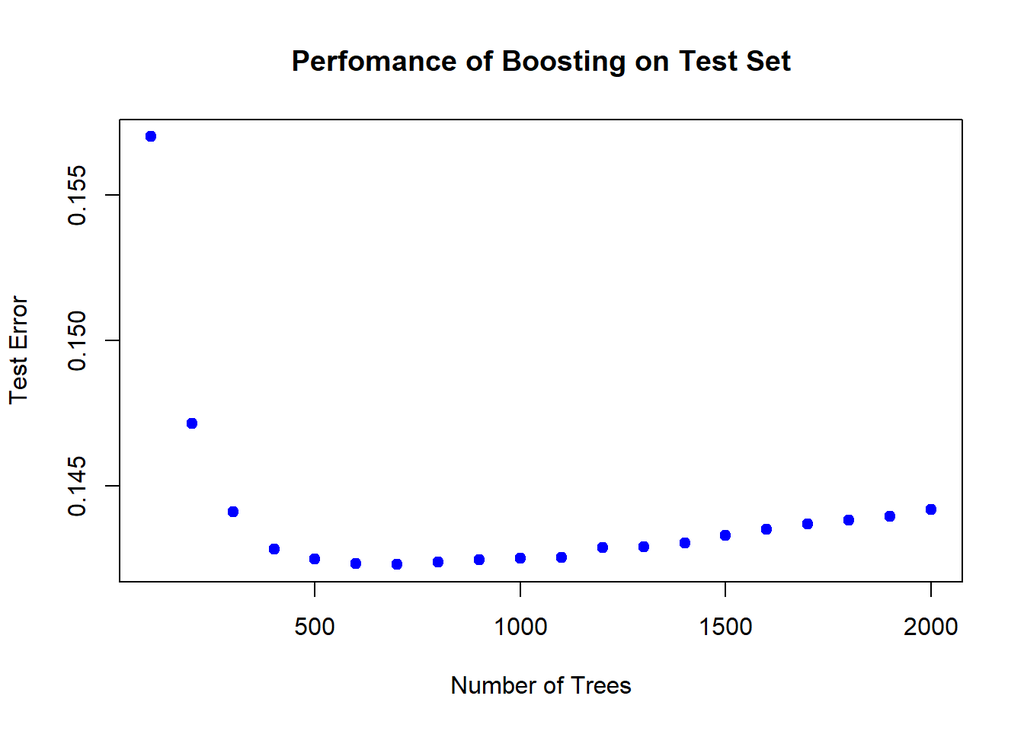

```r
a=data.frame(test.error)
#Représentation de l'évolution  de ces erreurs moyennes par centaines d'abres

plot(n.trees , test.error , pch=19,col="blue",xlab="Number of Trees",ylab="Test Error", main = "Perfomance of Boosting on Test Set")
```

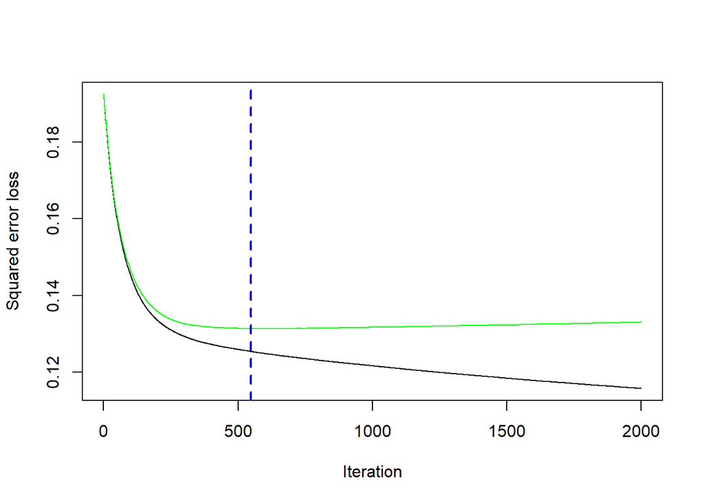

```
## [1] 547
```

```r
# Représentation graphique de la loss function loss function sur la table de test (vert) et d'entraînement (noir)
gbm.perf(grad.boost, method = "cv")
```

```r
set.seed(496)
#Déterminons les paramètres optimaux de notre gradient boosting machine

hyper_grid <- expand.grid(
  shrinkage = c(.01, .1, .3),
  interaction.depth = c(1, 3, 5),
  n.minobsinnode = c(5, 10, 15),
  bag.fraction = c(.65, .8, 1),
  optimal_trees = 0 ,             # paramètre qui sera remplit par la suite une fois le nombre optimal d'arbre déterminé
  min_RMSE = 0                     # de la même facon on cherchera le RMSE le plus petit pour sélectionner nos paramètres
)


# Préparation de nos données d'entraînement conformément à l'algorithme.
train_val_index <- sample(1:nrow(train_val), nrow(train_val))
train_gbm<- train_val[train_val_index, ]

# grid search
for(i in 1:nrow(hyper_grid)) {


  set.seed(496)

  # Entrâinement
  gbm.tune <- gbm(
    formula = Churn ~ .,
    distribution = "bernoulli",
    data = train_gbm,
    n.trees = 1000,
    interaction.depth = hyper_grid$interaction.depth[i],
    shrinkage = hyper_grid$shrinkage[i],
    n.minobsinnode = hyper_grid$n.minobsinnode[i],
    bag.fraction = hyper_grid$bag.fraction[i],
    train.fraction = .75,
    verbose = FALSE
  )

  # Ajout des paramètres signalant l'optimalité
  hyper_grid$optimal_trees[i] <- which.min(gbm.tune$valid.error)
  hyper_grid$min_RMSE[i] <- sqrt(min(gbm.tune$valid.error))
}
# Paramètres optimaux
hyper_grid %>%
  dplyr::arrange(min_RMSE) %>%
  head(5)
```

```
##   shrinkage interaction.depth n.minobsinnode bag.fraction optimal_trees
## 1       0.3                 3              5         0.80            34
## 2       0.3                 1             10         0.65           180
## 3       0.3                 1             15         0.65           174
## 4       0.3                 3             15         0.80            23
## 5       0.3                 3             10         0.80            22
##    min_RMSE
## 1 0.8903593
## 2 0.8907314
## 3 0.8908950
## 4 0.8910015
## 5 0.8910879
```

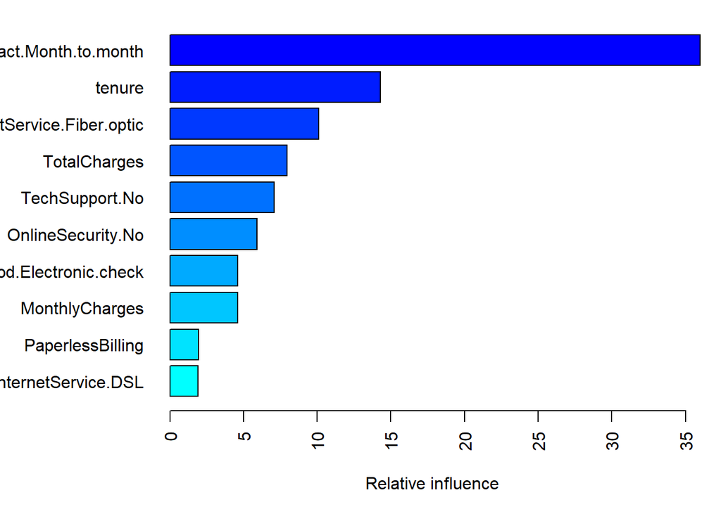

```
##                                                                             var
## Contract.Month.to.month                                 Contract.Month.to.month
## tenure                                                                   tenure
## InternetService.Fiber.optic                         InternetService.Fiber.optic
## TotalCharges                                                       TotalCharges
## TechSupport.No                                                   TechSupport.No
## OnlineSecurity.No                                             OnlineSecurity.No
## PaymentMethod.Electronic.check                   PaymentMethod.Electronic.check
## MonthlyCharges                                                   MonthlyCharges
## PaperlessBilling                                               PaperlessBilling
## InternetService.DSL                                         InternetService.DSL
## Contract.Two.year                                             Contract.Two.year
## nb_services                                                         nb_services
## MultipleLines.No                                               MultipleLines.No
## OnlineBackup.No                                                 OnlineBackup.No
## SeniorCitizen                                                     SeniorCitizen
## Dependents                                                           Dependents
## StreamingTV.Yes                                                 StreamingTV.Yes
## Contract.One.year                                             Contract.One.year
## StreamingMovies.Yes                                         StreamingMovies.Yes
## PaymentMethod.Credit.card..automatic.     PaymentMethod.Credit.card..automatic.
## PhoneService.No                                                 PhoneService.No
## gender                                                                   gender
## Partner                                                                 Partner
## PhoneService.Yes                                               PhoneService.Yes
## MultipleLines.No.phone.service                   MultipleLines.No.phone.service
## MultipleLines.Yes                                             MultipleLines.Yes
## InternetService.No                                           InternetService.No
## OnlineSecurity.No.internet.service           OnlineSecurity.No.internet.service
## OnlineSecurity.Yes                                           OnlineSecurity.Yes
## OnlineBackup.No.internet.service               OnlineBackup.No.internet.service
## OnlineBackup.Yes                                               OnlineBackup.Yes
## DeviceProtection.No                                         DeviceProtection.No
## DeviceProtection.No.internet.service       DeviceProtection.No.internet.service
## DeviceProtection.Yes                                       DeviceProtection.Yes
## TechSupport.No.internet.service                 TechSupport.No.internet.service
## TechSupport.Yes                                                 TechSupport.Yes
## StreamingTV.No                                                   StreamingTV.No
## StreamingTV.No.internet.service                 StreamingTV.No.internet.service
## StreamingMovies.No                                           StreamingMovies.No
```

[output cut: 31 more lines]

```
## OnlineSecurity.No.internet.service       0.00000000
## OnlineSecurity.Yes                       0.00000000
## OnlineBackup.No.internet.service         0.00000000
## OnlineBackup.Yes                         0.00000000
## DeviceProtection.No                      0.00000000
## DeviceProtection.No.internet.service     0.00000000
## DeviceProtection.Yes                     0.00000000
## TechSupport.No.internet.service          0.00000000
## TechSupport.Yes                          0.00000000
## StreamingTV.No                           0.00000000
## StreamingTV.No.internet.service          0.00000000
## StreamingMovies.No                       0.00000000
## StreamingMovies.No.internet.service      0.00000000
## PaymentMethod.Bank.transfer..automatic.  0.00000000
## PaymentMethod.Mailed.check               0.00000000
```

```r
hyper_grid=hyper_grid[order(hyper_grid$min_RMSE),]


# Entraînement du GBM avec paramètres optimaux réinseré directement dans l'algorithme d'entraînement.
gbm.fit.final <- gbm(
  formula = Churn ~ .,
  distribution = "bernoulli",
  data = train_gbm,
  n.trees = hyper_grid[1,5],
  interaction.depth = hyper_grid[1,2],
  shrinkage = hyper_grid[1,1],
  n.minobsinnode = hyper_grid[1,3],
  bag.fraction = hyper_grid[1,4],
  train.fraction = 1,
  verbose = FALSE
  )

# Importance des variables
par(mar = c(5, 8, 1, 1))
summary(
  gbm.fit.final,
  cBars = 10,
  method = relative.influence, # also can use permutation.test.gbm
  las = 2
  )
```

```r
#Prediction
predgbm <- predict(gbm.fit.final, n.trees = gbm.fit.final$n.trees, X_test,type="response")
head(predgbm,5)
```

```
## [1] 0.48401835 0.07740953 0.75276774 0.22294812 0.46851831
```

```r
predictiongbm=as.factor(ifelse(predgbm>0.51,1,0))

#Resultats
confusionMatrix(predictiongbm,y_test)
```

```
## Confusion Matrix and Statistics
##
##           Reference
## Prediction   0   1
##          0 926 200
##          1  89 193
##
##                Accuracy : 0.7947
##                  95% CI : (0.7727, 0.8156)
##     No Information Rate : 0.7209
##     P-Value [Acc > NIR] : 1.160e-10
##
##                   Kappa : 0.4416
##
##  Mcnemar's Test P-Value : 9.762e-11
##
##             Sensitivity : 0.9123
##             Specificity : 0.4911
##          Pos Pred Value : 0.8224
##          Neg Pred Value : 0.6844
##              Prevalence : 0.7209
##          Detection Rate : 0.6577
##    Detection Prevalence : 0.7997
##       Balanced Accuracy : 0.7017
##
##        'Positive' Class : 0
##
```

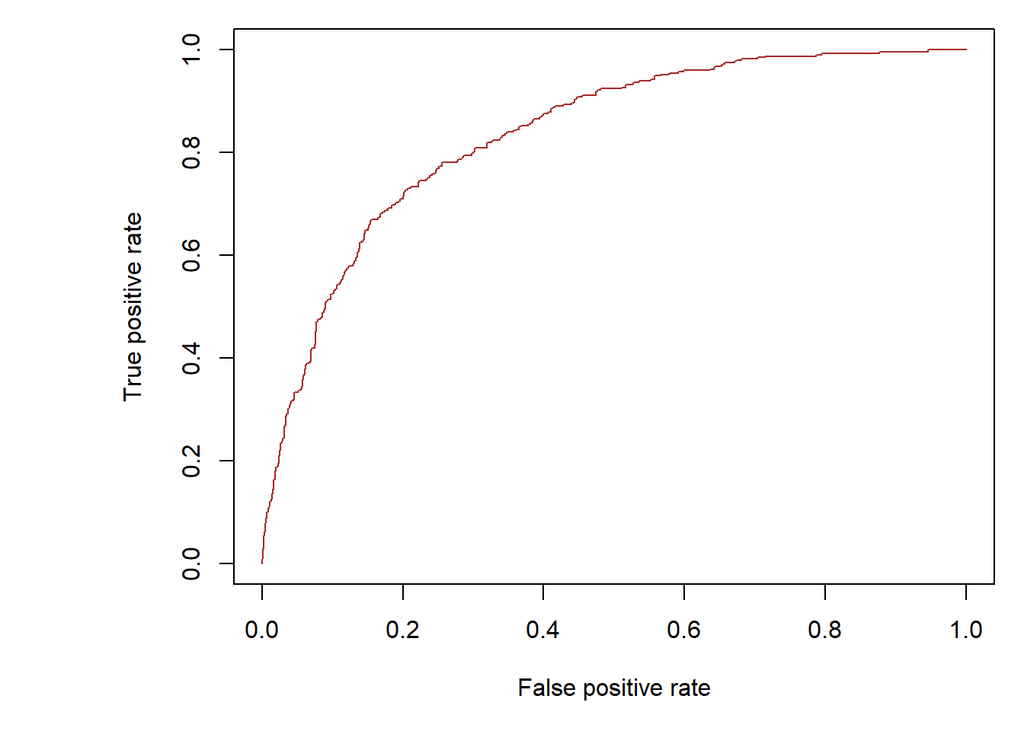

```r
Errors=prediction(predgbm,y_test)
ROC <- performance(Errors,"tpr","fpr")
plot(ROC,col="brown")
```

```r
AUC <- performance(Errors,"auc")
AUC<-as.numeric(AUC@y.values)
AUC
```

```
## [1] 0.8347372
```

Après le premier algorithme qui nous a donné une idée assez large du nombre d’arbre où se situerait notre meilleur prédiction, nous décidons d’améliorer notre algorithme en lui proposant une liste de différents paramètres qu’il pourra modifier pour trouver la meilleur prédiction. Ces paramètres seront sélectionnés sur le critères de la combinaison qui donnera le plus faible RMSE associé.

Voici un petit glossaire des paramètres chalengés:

#### le Shinkage est l’équivalent du learning rate qui contrôle la descente de radient. Cette valeur est comprise entre 0 et 1 et est en général optimale vers 0,1.

#### interaction.depth :Le nombre de feuille maximal accepté. Etant donné la théorie du boosting qui veut agréger des prédicteurs faibles, tous les arbres crées ne doivent pas être trop profond. N.B : un profondeur égale à 1 equivaut en principe à plus ou moins un GLM.

#### optimal_trees : le nombre d’arbre permettant d’obtenir le meilleur résultat sur ce jeu de données. Il s’agit donc du nombre d’arbre optimal.

#### RMSE: erreur quadratique moyenne que nous souhaitons minimiser ici. Il s’agit de la racine carrée du carré moyen des erreurs.

#### n.minobsinnode : Le nombre minimal d’observation dans le dernier noeud de l’arbre.

#### bag.fraction: part des observations du jeu d’entrâinement sélectionné aléatoirement. En temps normal, se paramètre est fixé à 0.5.

# Conclusion

L’apprentissage supervisé semble plus efficace que le non supervisé. De même nous préfèrerons utiliser un gradient boosting pour déterminer nos clients Churners. Nous avons pu voir que pour la représentation, il est plus parlant d’utiliser une classification, cependant la régression (comme dans le gradient boosting) pourrait nous permettre de mieux cibler nos churners. En effet, un service commercial pourrait par exemple nous demander de sortir un nombre précis de churners par mois, tout en limitant le nombre de faux pour ne pas passer d’appel inutile par exemple, dans ce cas la on fera varier notre probabilité seuil pour obtenir un nombre de churner avec très peu d’erreurs. Dans ce cas la, nous cherchons utilisons la DataScience comme vecteur de productivité

```r
"finish"
```

```
## [1] "finish"
```